# Zooming out: Toward a macro-socio-ecology for the natural resource use of nations

Monday, May 11, 2015

## Background

## Climate change impacts on wildlife

[figure not shown]

## Applied evolutionary biology

[figure not shown]

## Next-generation ecology - INNGE

- **GCIP**
  - Global Reach
  - Community Participation
  - Continuous Innovation
  - Open Platform

[figure not shown]

## Current focus

- How do general patterns of ecology (and evolution) relate to the real world?
  - How can their real world relevance be improved?

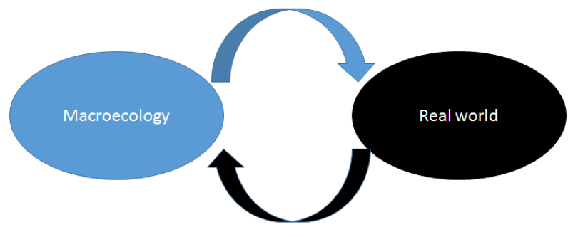

## Macroecology

[figure not shown]

## Human macroecology 101

- energetic limits to growth

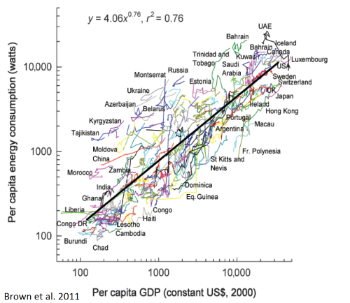

## Human macroecology 101

- earth has a carrying capacity (AKA planetary boundaries)

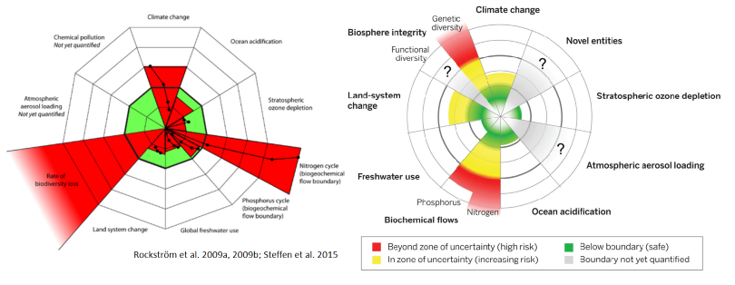

## Two challenges for a macro-socio-ecology

- **Technical** Globalization of the economy influences the structure of consumption
  - Sub-global scale
- **Conceptual** Integrate social aspects into human macroecology
  - Local to global scale

## Ongoing research on a macro-socio-ecology for nations

## Two ongoing projects

- Take advantage of improvements in measuring consumption in the globalized economy
- Compare long-standing "*socio-ecological*" hypotheses from across disciplines
  - Trends in (1) structure and (2) socio-ecological efficiency of consumption

## Structure of consumption

- global value chains

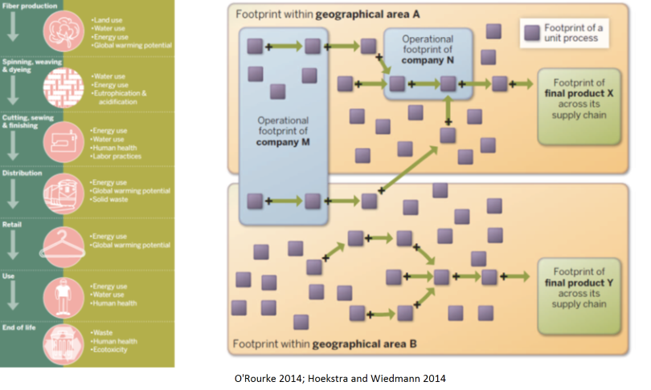

## Structure of consumption

- measuring consumption

"*Trends show that resource productivity measured in this way has increased in . . . , **suggesting that a relative, and even absolute, decoupling of economic growth and resource** use has been achieved.*"

"*However, **the scope of these measures is limited to the amount of materials directly used by an economy**. It does not include the upstream raw materials related to imports and exports originating from outside of the focal economy*." (Wiedmann et al. 2013)

## Structure of consumption

- macroecology

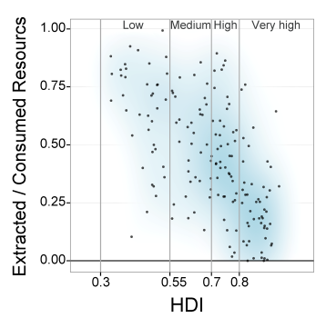

## Structure of consumption

- improvements

[figure not shown]

## Change in structure can influence evalution of long-standing hypotheses

- Environmental quality and per capita GDP (Environmental Kuznets Curve)
  - environmental pollution has an inverse "U" shape with affluence

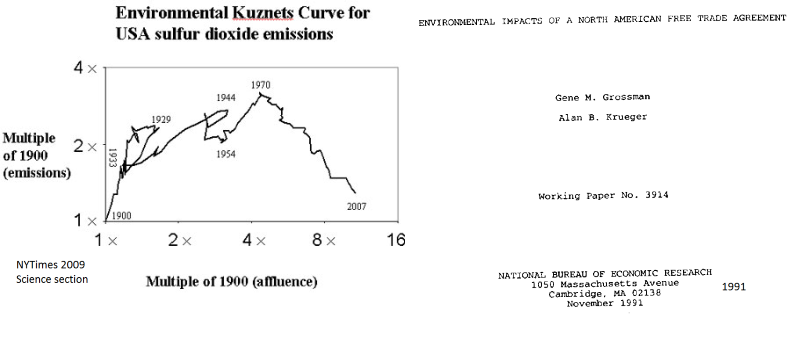

## Efficiency?

- How are resources turned into social and economic outcomes?
- How can social and economic factors help improve efficiency?

## Efficiency of consumption

- macroecology

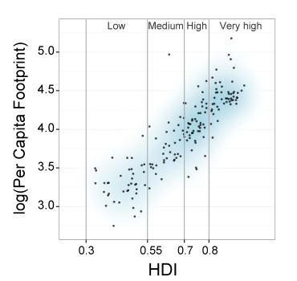

## Efficiency of consumption

- when national consumption increases GDP goes up

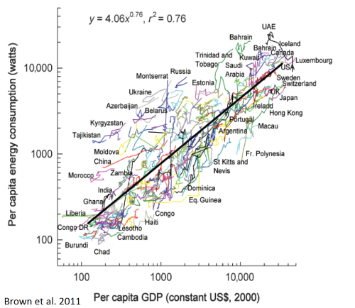

## Efficiency of consumption

- … but not always

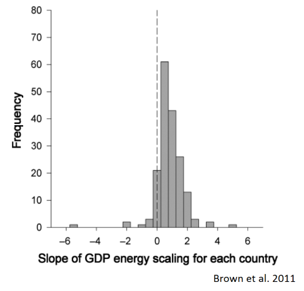

## Efficiency of consumption

- how does change in national consumption contribute to?
  - shape of income distribution
  - median income
  - health & well-being
  - etc. etc.

## Need for a macro-socio-ecology?

- Importance:
  - Provide an overview and a compass for new visions
- Challenges:
  - Fragmentation of field
  - Integrated studies have a small-scale history

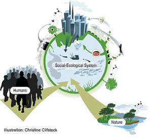

## Natural resource studies

- Contested field
- Disparate methodologies
- *"As in any contested field a wide array of theories have emerged to describe the relationship among the variables of interest, and each of these theories leads to starkly different conclusions and policy recommendations."* (Sherbinin et al. 2007)

## The socio-ecological system

- small scale and simple interactions

[figure not shown]

## Path forward?

- Doughnut economics

[figure not shown]

## Measuring the doughnut?

- Outcome or (outcome and resources)
  - i.e. health improvements or health improvements per resource
- Back to basics I=PAT
- Impact on the environment
  - Population
  - Affluence
  - Technology

## The social equivalent of IPAT is ?DPAE?

- D = PAE (Parris and Kates 2003)
- Development
  - Population
  - Affluence
  - Equity
- Two variants:
- Resource intensities (emissions per unit resource)
- Measures as proxies (PAT = I)
- ?New measure, simple measure for DPAE? *Overall efficiency (development outcome / consumed resources)*

## Perspectives - why important?

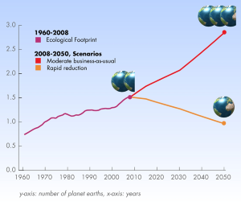

## Thank you

- Stay tuned for *actual results*

[figure not shown]